# Classificazione di fiori di Iris nelle diverse specie

**Progetto per il corso di Programmazione di Applicazioni Data Intensive**  
Laurea in Ingegneria e Scienze Informatiche, Università di Bologna

Lorenzo Paganelli  
lorenzo.paganelli3@studio.unibo.it

## Introduzione

*Iris* è un genere di piante della famiglia delle Iridaceae, che comprende oltre 300 specie. Noi prendiamo in considerazione unicamente tre specie: **Iris virginica**, **Iris setosa** e **Iris versicolor**, i cui fiori sono visibili nell'immagine seguente

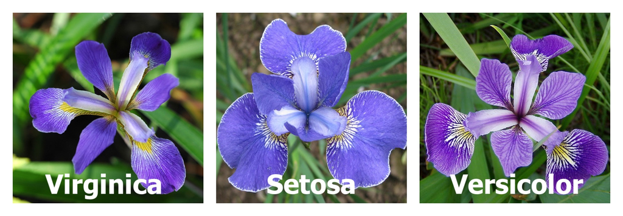

Ciò che vogliamo fare è classificare i fiori di iris nelle diverse specie menzionate sopra, sulla base di un insieme di caratteristiche. In particolare vengono considerate quattro caratteristiche per ciascun fiore:

- **`SepalLengthCm`**: Lunghezza del sepalo in cm
- **`SepalWidthCm`**: Larghezza del sepalo in cm
- **`PetalLengthCm`**: Lunghezza del petalo in cm
- **`PetalWidthCm`**: Larghezza del petalo in cm

Si prendono cioè in considerazione due tratti caratteristici del fiore: il **sepalo** e il **petalo**, per ciascuno di questi si conosce la lunghezza e la larghezza. Si sappia che il **sepalo** è una foglia modificata che fa parte del calice del fiore, si veda la figura sotto

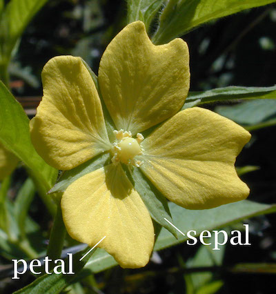

## Analisi esplorativa

Importiamo le librerie necessarie e scarichiamo il dataset, se non è già presente

```python
%matplotlib inline
import numpy as np
import pandas as pd
import matplotlib.pyplot as plt
```

```python
import os.path
if not os.path.exists("Iris.csv"):
    from urllib.request import urlretrieve
    urlretrieve("https://bitbucket.org/paagamelo/iris-species/downloads/Iris.csv", "Iris.csv")
```

Il dataset viene convertito in un DataFrame pandas, per renderlo meglio fruibile

```python
iris = pd.read_csv("Iris.csv", index_col="Id", dtype={"Species": "category"})
```

Osserviamo un estratto del DataFrame: questo ha 5 colonne, come intuibile, contenenti le quattro caratteristiche menzionate prima e l'informazione sulla specie di ciascuna osservazione

```python
iris.head(3)
```

| Id | SepalLengthCm | SepalWidthCm | PetalLengthCm | PetalWidthCm | Species |
| --- | --- | --- | --- | --- | --- |
| 1 | 5.1 | 3.5 | 1.4 | 0.2 | Iris-setosa |
| 2 | 4.9 | 3.0 | 1.4 | 0.2 | Iris-setosa |
| 3 | 4.7 | 3.2 | 1.3 | 0.2 | Iris-setosa |

Osserviamo ora la *forma* del DataFrame: disponiamo di 150 osservazioni in tutto, quindi il dataset è piuttosto ridotto. Tipicamente i modelli di conoscenza allenati su insiemi di dati ridotti tendono ad andare facilmente in overfitting, questo perchè meno dati ci sono tanti più sono i modelli che riescono a descrivere lo stesso fenomeno

```python
iris.shape
```

```
(150, 5)
```

Verifichiamo la presenza di valori mancanti, in questo caso non ce ne sono

```python
iris.isnull().any()
```

```
SepalLengthCm    False
SepalWidthCm     False
PetalLengthCm    False
PetalWidthCm     False
Species          False
dtype: bool
```

Con il metodo `describe()` otteniamo una serie di statistiche sulle colonne numeriche del DataFrame, cioè tutte a parte quella relativa alla specie

```python
iris.describe()
```

|  | SepalLengthCm | SepalWidthCm | PetalLengthCm | PetalWidthCm |
| --- | --- | --- | --- | --- |
| count | 150.000000 | 150.000000 | 150.000000 | 150.000000 |
| mean | 5.843333 | 3.054000 | 3.758667 | 1.198667 |
| std | 0.828066 | 0.433594 | 1.764420 | 0.763161 |
| min | 4.300000 | 2.000000 | 1.000000 | 0.100000 |
| 25% | 5.100000 | 2.800000 | 1.600000 | 0.300000 |
| 50% | 5.800000 | 3.000000 | 4.350000 | 1.300000 |
| 75% | 6.400000 | 3.300000 | 5.100000 | 1.800000 |
| max | 7.900000 | 4.400000 | 6.900000 | 2.500000 |

Una prima informazione ricavabile è che i dati relativi al petalo risultano molto più *variabili* di quelli relativi al sepalo. Infatti la deviazione standard media delle informazioni sul **sepalo** è:

```python
iris.describe().loc["std", ["SepalLengthCm", "SepalWidthCm"]].mean()
```

```
0.6308302196700183
```

Mentre la deviazione standard media delle informazioni sul **petalo** è circa il doppio:

```python
iris.describe().loc["std", ["PetalLengthCm", "PetalWidthCm"]].mean()
```

```
1.2637905808265515
```

Consideriamo ora la colonna `Species`, mostrando la frequenza delle diverse specie in un grafico a torta. Osserviamo che il dataset è perfettamente bilanciato

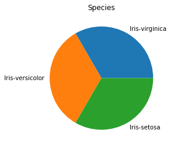

```python
chart = iris["Species"].value_counts().plot.pie()
chart.set_title("Species")
chart.set_ylabel('')
```

Analizziamo ora le colonne numeriche del DataFrame, visualizzando per ciascuna un istogramma e una raccolta di statistiche ottenibili con il metodo `describe()`

Osserviamo che i dati relativi alla **lunghezza del *sepalo*** presentano tre picchi distinti, potrebbe essere che ciascun picco sia relativo a una delle tre specie. In realtà, come vedremo poi, non è così

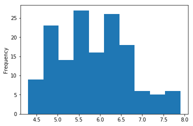

```python
iris["SepalLengthCm"].plot.hist()
```

```python
iris["SepalLengthCm"].describe()
```

```
count    150.000000
mean       5.843333
std        0.828066
min        4.300000
25%        5.100000
50%        5.800000
75%        6.400000
max        7.900000
Name: SepalLengthCm, dtype: float64
```

Al contrario, i dati relativi alla **larghezza del *sepalo*** risultano ben distribuiti, mostrando un "andamento" gaussiano

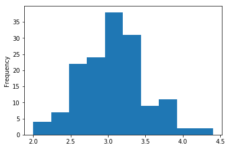

```python
iris["SepalWidthCm"].plot.hist()
```

```python
iris["SepalWidthCm"].describe()
```

```
count    150.000000
mean       3.054000
std        0.433594
min        2.000000
25%        2.800000
50%        3.000000
75%        3.300000
max        4.400000
Name: SepalWidthCm, dtype: float64
```

Osserviamo poi che i dati relativi alla **lunghezza del *petalo*** presentano un andamento chiaramente bimodale, ossia sono presenti due picchi ben distinti

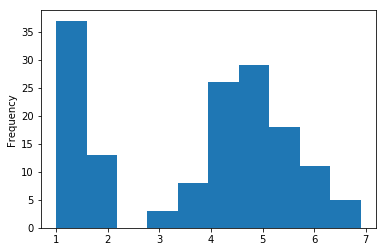

```python
iris["PetalLengthCm"].plot.hist()
```

```python
iris["PetalLengthCm"].describe()
```

```
count    150.000000
mean       3.758667
std        1.764420
min        1.000000
25%        1.600000
50%        4.350000
75%        5.100000
max        6.900000
Name: PetalLengthCm, dtype: float64
```

Lo stesso si può dire dei dati relativi alla **larghezza del *petalo***

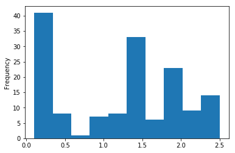

```python
iris["PetalWidthCm"].plot.hist()
```

```python
iris["PetalWidthCm"].describe()
```

```
count    150.000000
mean       1.198667
std        0.763161
min        0.100000
25%        0.300000
50%        1.300000
75%        1.800000
max        2.500000
Name: PetalWidthCm, dtype: float64
```

Vogliamo ora mostrare la correlazione tra alcune coppie di feature, visualizzando un piano cartesiano con una feature su ciascun asse e con le nostre osservazioni colorate in modo differente a seconda della specie. Definiamo una funzione che ci permetta di fare questo

```python
species_colors = {"Iris-virginica": "firebrick", "Iris-setosa": "royalblue", "Iris-versicolor": "seagreen"}
def plot_features(x, y):
    for species, color in species_colors.items():
        plt.scatter(x[iris["Species"] == species], y[iris["Species"] == species], c=color, label=species, alpha=0.8)
    plt.xlabel(x.name)
    plt.ylabel(y.name)
    plt.legend()
```

Visualizziamo prima le informazioni sul **petalo** (lunghezza e larghezza), osserviamo che queste già da sole ci permettono di distinguere le diverse specie in modo piuttosto efficace

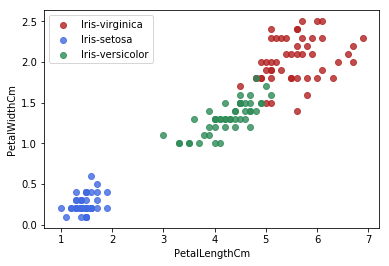

```python
plot_features(iris["PetalLengthCm"], iris["PetalWidthCm"])
```

Visualizziamo anche le informazioni sul **sepalo** (lunghezza e larghezza): queste al contrario non permettono di distinguere i nostri dati in modo soddisfacente. In particolare le osservazioni di *iris virginica* e *iris versicolor* non vengono separate

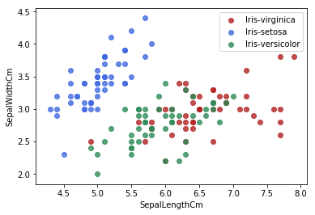

```python
plot_features(iris["SepalLengthCm"], iris["SepalWidthCm"])
```

Visualizziamo ora le informazioni relative alla **lunghezza** dei due tratti, anche queste ci permettono di separare i nostri dati in modo efficace

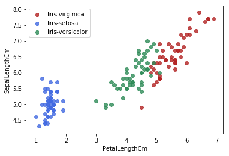

```python
plot_features(iris["PetalLengthCm"], iris["SepalLengthCm"])
```

Lo stesso si può dire delle informazioni relative alla **larghezza** dei tratti

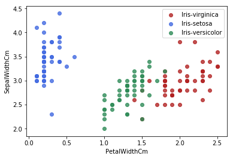

```python
plot_features(iris["PetalWidthCm"], iris["SepalWidthCm"])
```

## Primo modello

Vogliamo costruire un primo modello usando unicamente le informazioni relative al **petalo** dei fiori (lunghezza e larghezza), in questo modo - avendo solo due feature - sarà possibile dare una rappresentazione grafica degli iperpiani trovati

Creiamo un nuovo DataFrame `iris_petal` ottenuto dal DataFrame originale rimuovendo le colonne relative al sepalo

```python
iris_petal = iris.copy()
iris_petal.drop(["SepalLengthCm", "SepalWidthCm"], axis=1, inplace=True)
```

Convertiamo la colonna categorica `Species` in una colonna numerica, assegnando a ciascuna specie un numero intero crescente partendo da 1. D'ora in poi si farà riferimento a tale numero come come "codice di una specie"

```python
species_codes = {"Iris-virginica": 1, "Iris-setosa": 2, "Iris-versicolor": 3}
iris_petal["Species"] = iris_petal["Species"].map(species_codes)
iris_petal["Species"].value_counts()
```

```
3    50
2    50
1    50
Name: Species, dtype: int64
```

Nel caso di classificazione multiclasse con iperpiani ci sono due approcci possibili:

- **One versus all** (o **one versus rest**)
- **Multinomial**

Nel nostro caso scegliamo l'approccio **one vs all**, questo prevede l'indivduazione di un numero di iperpiani pari al numero di classi (nel nostro caso 3): ciascuno deve separare una classe dal resto del mondo. Inoltre l'individuazione di ogni iperpiano è indipendente dalle altre

Iniziamo con l'individuare un iperpiano che separi le osservazioni di *iris virginica* dalle altre, creiamo una serie `target` in cui le osservazioni della specie di interesse conservano il proprio codice, mentre le osservazioni relative al resto del mondo presentano valore 0

```python
target = iris_petal["Species"].copy()
target[iris["Species"] != "Iris-virginica"] = 0
target.value_counts()
```

```
0    100
1     50
Name: Species, dtype: int64
```

Definiamo una funzione che ci permetta di visualizzare in un grafico quali osservazioni si vogliono separare dal resto del mondo

```python
def plot_target(label):
    plt.scatter(iris["PetalLengthCm"][target != 0], iris["PetalWidthCm"][target != 0], c="firebrick", label=label, alpha=0.8)
    plt.scatter(iris["PetalLengthCm"][target == 0], iris["PetalWidthCm"][target == 0], c="royalblue", label="others", alpha=0.8)
    plt.legend()
    plt.xlabel("PetalLengthCm")
    plt.ylabel("PetalWidthCm")
```

Nonostante le osservazioni di *iris virginica* non siano linearmente separabili dal resto del mondo, visivamente è chiaro che possiamo comunque usare una retta come *decision boundary* in modo efficace

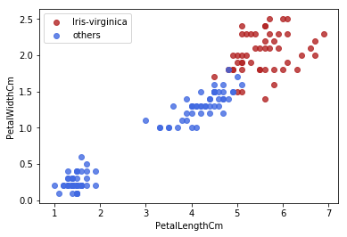

```python
plot_target("Iris-virginica")
```

Separiamo i nostri dati in training set e validation set, usiamo la serie `target` come colonna y da predire

```python
from sklearn.model_selection import train_test_split
X_train, X_val, y_train, y_val = train_test_split(
    iris_petal.drop(["Species"], axis=1),
    target,
    test_size=1/3, random_state=42
)
```

Silenziamo i warning che risultano piuttosto fastidiosi se si sta eseguendo il codice in jupyter

```python
import warnings
warnings.filterwarnings('ignore')
```

Scegliamo un modello "base" per la classificazione: il `Perceptron`. Il parametro `max_iter` indica il numero massimo di iterazioni dopo le quali l'algoritmo arriva a convergenza, di default questo è 1000, lo aumentiamo in modo da avere più precisione

```python
from sklearn.linear_model import Perceptron
model1 = Perceptron(max_iter=1000000)
model1.fit(X_train, y_train)
model1.score(X_val, y_val)
```

```
1.0
```

Definiamo una funziona che ci permetta di visualizzare il *decision boundary* che abbiamo ricavato

```python
def plot_decision_boundary(X, y, model, c="r"):
    # Step size of the mesh. Decrease to increase the quality of the VQ.
    h = .01     # point in the mesh [x_min, m_max]x[y_min, y_max].

    # Plot the decision boundary. For that, we will assign a color to each
    x_min, x_max = X.iloc[:, 0].min() - 1, X.iloc[:, 0].max() + 1
    y_min, y_max = X.iloc[:, 1].min() - 1, X.iloc[:, 1].max() + 1
    xx, yy = np.meshgrid(np.arange(x_min, x_max, h), np.arange(y_min, y_max, h))

    # Obtain labels for each point in mesh using the model.
    Z = model.predict(np.c_[xx.ravel(), yy.ravel()])

    x_min, x_max = X.iloc[:, 0].min() - 1, X.iloc[:, 0].max() + 1
    y_min, y_max = X.iloc[:, 1].min() - 1, X.iloc[:, 1].max() + 1
    xx, yy = np.meshgrid(np.arange(x_min, x_max, 0.01),
                         np.arange(y_min, y_max, 0.01))

    Z = model.predict(np.c_[xx.ravel(), yy.ravel()]).reshape(xx.shape)

    #plt.scatter(X.iloc[:, 0], X.iloc[:, 1], c=iris["Species"].map(species_colors), alpha=0.8)
    xlim, ylim = plt.xlim(), plt.ylim()
    plt.xlim(xlim); plt.ylim(ylim)
    plt.contour(xx, yy, Z, alpha=0.4, colors=c)
```

Visivamente il risultato è soddisfacente

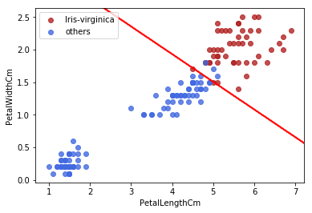

```python
plot_target("Iris-virginica")
plot_decision_boundary(iris_petal.drop(["Species"], axis=1), target, model1)
```

Procediamo ora con l'individuazione di un iperpiano che separi le osservazioni di *iris setosa* dalle altre, aggiorniamo la serie `target` di conseguenza

```python
target = iris_petal["Species"].copy()
target[iris["Species"] != "Iris-setosa"] = 0
target.value_counts()
```

```
0    100
2     50
Name: Species, dtype: int64
```

In questo caso le osservazioni di interesse sono linearmente separabili dal resto del mondo

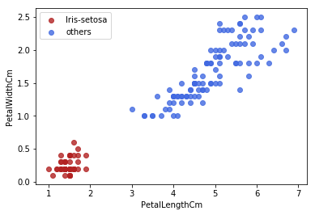

```python
plot_target("Iris-setosa")
```

Dividiamo dunque i dati in training e validation set (è necessario farlo ancora in quanto la colonna target è mutata) e addestriamo un modello lineare, allo stesso modo di prima

```python
X_train, X_val, y_train, y_val = train_test_split(
    iris_petal.drop(["Species"], axis=1),
    target,
    test_size=1/3, random_state=42
)
```

```python
model2 = Perceptron()
model2.fit(X_train, y_train)
model2.score(X_val, y_val)
```

```
1.0
```

Visualizziamo infine l'iperpiano trovato

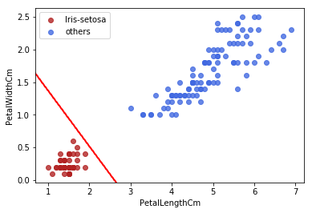

```python
plot_target("Iris-setosa")
plot_decision_boundary(iris_petal.drop(["Species"], axis=1), target, model2)
```

Vogliamo infine individuare un iperpiano che separi le osservazioni di *iris versicolor* dalle altre

```python
target = iris_petal["Species"].copy()
target[iris["Species"] != "Iris-versicolor"] = 0
target.value_counts()
```

```
0    100
3     50
Name: Species, dtype: int64
```

In questo caso le osservazioni di interesse *non* sono linearmente separabili dal resto del mondo, ne tantomento possiamo impiegare una retta come decision boundary in modo efficace. E' dunque inevitabile introdurre delle feature polinomiali, in questo caso è sufficiente fermarsi al secondo grado. Ciò che si sta facendo con questa operazione è mappare i nostri dati in uno spazio a più dimensioni, in cui questi siano separabili in modo efficace con un iperpiano (e dunque con una funzione lineare). Visualizzando tale iperpiano in due dimensioni questo risulterà chiaramente in una funzione non lineare

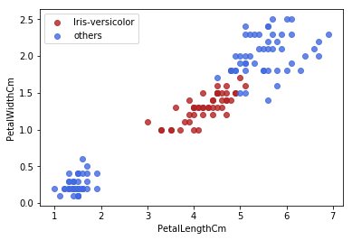

```python
plot_target("Iris-versicolor")
```

Dividiamo i dati in training set e validation set ancora una volta

```python
X_train, X_val, y_train, y_val = train_test_split(
    iris_petal.drop(["Species"], axis=1),
    target,
    test_size=1/3, random_state=42
)
```

Facciamo uso del filtro `PolynomialFeatures` che ci permette di ricavare feature polinomiali dai nostri dati, lo inseriamo all'interno di una `Pipeline` e alleniamo il nostro modello

```python
from sklearn.pipeline import Pipeline
from sklearn.preprocessing import PolynomialFeatures

model3 = Pipeline([
    ("poly", PolynomialFeatures(degree=2, include_bias=False)),
    ("perc", Perceptron(max_iter=100000))
])
model3.fit(X_train, y_train)
model3.score(X_val, y_val)
```

```
0.98
```

Visualizziamo il decision boundary trovato, come anticipato in due dimensioni questo risulterà in una funzione non lineare

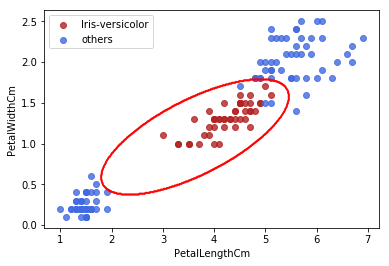

```python
plot_target("Iris-versicolor")
plot_decision_boundary(iris_petal.drop(["Species"], axis=1), target, model3)
```

Abbiamo trovato tre iperpiani: ciascuno separa una classe (una specie) dal resto del mondo, visualizziamo congiuntamente i tre decision boundary

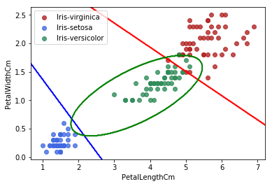

```python
plot_features(iris["PetalLengthCm"], iris["PetalWidthCm"])
plot_decision_boundary(iris_petal.drop(["Species"], axis=1), target, model1, c="r")
plot_decision_boundary(iris_petal.drop(["Species"], axis=1), target, model2, c="b")
plot_decision_boundary(iris_petal.drop(["Species"], axis=1), target, model3, c="g")
```

Possiamo usarli in modo congiunto per classificare un'osservazione in una delle tre specie, la regola di fusione è la seguente: ad ogni istanza $x$ si assegna la classe $y$ corrispondente al piano $j$ che massimizza $$ y = \underset{j = 1,...,C}{\operatorname{argmax}}{b_j + x^T w_j} $$

Definiamo una funzione che faccia questa operazione, si noti che non usiamo la funzione `predict(x)` dei modelli, in quanto restituirebbe un valore binario, usiamo invece la funzione `decision_function(x)` che restituisce una stima della confidenza con la quale il modello in questione classifica l'osservazione in esame. La classe finale sarà quella relativa al modello con confidenza maggiore

```python
def ovr_predict(x):
    confidence1 = model1.decision_function(x)
    confidence2 = model2.decision_function(x)
    confidence3 = model3.decision_function(x)
    max_confidence = confidence1
    c = 1
    if confidence2 > max_confidence:
        max_confidence = confidence2
        c = 2
    if confidence3 > max_confidence:
        max_confidence = confidence3
        c = 3
    return c

def ovr_predict_aggregate(X):
    y = []
    for i in range(0, len(X)):
        if isinstance(X, pd.DataFrame):
            y.append(ovr_predict(X.iloc[[i], :]))
        else:
            y.append(ovr_predict(X[[i], :]))
    return np.array(y)
```

Costruiamo ancora una volta training set e validation set, questa volta usando la colonna `Species` di `iris_petal` (e non `target`) come colonna y. Questo vuol dire che le osservazioni saranno divise nelle tre classi

```python
X_train, X_val, y_train, y_val = train_test_split(
    iris_petal.drop(["Species"], axis=1),
    iris_petal["Species"],
    test_size=1/3, random_state=42
)
```

Misuriamo l'accuratezza del modello ottenuto: è del 98%

```python
hits = y_val == ovr_predict_aggregate(X_val)
hits.mean()
```

```
0.98
```

Essendo che nei modelli di classificazione l'accuratezza non è l'unica metrica da prendere in considerazione, costruiamo la **matrice di confusione** per il nostro modello. Si ricorda che la matrice di confusione è una matrice in cui la cella in posizione (i,j) indica quanti esempi della classe i-esima sono stati etichettati dal classificatore come di classe j-esima

```python
from sklearn.metrics import confusion_matrix
y_val_pred = ovr_predict_aggregate(X_val)
cm = confusion_matrix(y_val, y_val_pred)
classes = ["Iris-virginica", "Iris-setosa", "Iris-versicolor"]
pd.DataFrame(cm, index=classes, columns=classes)
```

|  | Iris-virginica | Iris-setosa | Iris-versicolor |
| --- | --- | --- | --- |
| Iris-virginica | 15 | 0 | 1 |
| Iris-setosa | 0 | 19 | 0 |
| Iris-versicolor | 0 | 0 | 15 |

Osserviamo che è presente un unico errore di classificazione, misuriamo ora precision e recall per ciascuna delle tre classi. Si ricorda che la **precision** relativa a una classe inidica la percentuale di esempi classificati come appartanenti a quella classe che sono realmente tali, la **recall** relativa a una classe indica la percentuale di osservazioni della classe in esame che sono stati classificati come tali

```python
from sklearn.metrics import precision_score, recall_score, f1_score

precision_score(y_val, y_val_pred, average=None)
```

```
array([1.    , 1.    , 0.9375])
```

```python
recall_score(y_val, y_val_pred, average=None)
```

```
array([0.9375, 1.    , 1.    ])
```

Come prevedibile già dalla matrice di confusione, i risultati sono piuttosto soddisfacenti. Misuriamo anche la **f1 score** per ciascuna classe, questa corrisponde a una media armonica di precision e recall

```python
f1_score(y_val, y_val_pred, average=None)
```

```
array([0.96774194, 1.        , 0.96774194])
```

Effettuiamo infine una **media delle diverse f1 score** per avere un unico valore che rispecchi l'efficacia del modello

```python
f1_score(y_val, y_val_pred, average="macro")
```

```
0.978494623655914
```

Il risultato ottenuto è piuttosto soddisfacente

L'ultima cosa che vogliamo fare è mostrare i *decision boundaries* "finali" ottenuti dalla fusione dei tre iperpiani, definiamo una funzione che ci permetta di farlo

```python
def plot_decision_boundaries(model):

    X = iris_petal.drop(["Species"], axis=1)
    y = iris["Species"].map(species_codes)

    def make_meshgrid(x, y, h=.02):
        x_min, x_max = x.min() - 1, x.max() + 1
        y_min, y_max = y.min() - 1, y.max() + 1
        xx, yy = np.meshgrid(np.arange(x_min, x_max, h), np.arange(y_min, y_max, h))
        return xx, yy

    def plot_contours(xx, yy, **params):
        Z = model(np.c_[xx.ravel(), yy.ravel()])
        Z = Z.reshape(xx.shape)
        out = plt.contourf(xx, yy, Z, **params)
        return out

    X0, X1 = X.iloc[:, 0], X.iloc[:, 1]
    xx, yy = make_meshgrid(X0, X1)
    plt.scatter(X0, X1, c=y, cmap=plt.cm.coolwarm, edgecolors='k')
    xlim, ylim = plt.xlim(), plt.ylim()
    plt.xlim(xlim); plt.ylim(ylim)

    plot_contours(xx, yy, alpha=0.4, cmap=plt.cm.coolwarm)
    plt.ylabel('PetalWidthCm')
    plt.xlabel('PetalLengthCm')
    #plt.show()
```

Osserviamo che, per quanto le nostre misure siano soddisfacenti, il modello finale ottenuto risulta piuttosto aderente ai dati. In particolare l'iperpiano usato per classificare le osservazioni di *iris versicolor* (in figura la regione rossa) potrebbe non essere così efficace su dati futuri, soprattutto se questi risultassero più *sparsi* di quelli attuali

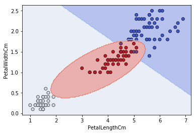

```python
plot_decision_boundaries(ovr_predict_aggregate) # this may take a while
```

## Modelli più complessi

I modelli allenati fino a questo momento usano solo una parte delle feature a nostra disposizione, inoltre non fanno uso di **standardizzazione** dei dati, **regolarizzazione** dei parametri degli iperpiani (in effetti è stato appena osservato che uno dei tre iperpiani trovati risulta troppo aderente ai dati, cioè è andato in overfitting), e le misure di cui sopra sono state calcolate dividendo i dati con il metodo hold-out, cioè partizionandoli una sola volta. Ciò che si vuole fare ora è allenare modelli più complessi che facciano uso di tutte le feature a nostra disposizione e delle tecniche citate sopra, le metriche di valutazione di questi modelli saranno calcolate con la k-fold cross validation, in modo da ottenere stime più robuste.

Si sappia che la classificazione multiclasse è supportata dai modelli di scikit learn, dunque quanto è stato fatto "a mano" fino a questo momento può essere effettuato in modo automatico

Dividiamo i dati in training e validation set, usando questa volta il DataFrame originale `iris`

```python
X_train, X_val, y_train, y_val = train_test_split(
    iris.drop(["Species"], axis=1),
    iris["Species"].map(species_codes),
    test_size=1/3, random_state=42
)
```

Scegliamo come primo algoritmo il `Perceptron`, usato anche in precedenza, introducendo però feature polinomiali, standardizzazione dei dati e regolarizzazione dei parametri. Utilizziamo la grid search per testare diverse combinazioni di iperparametri e trovare quella che fornisce risultati migliori, in particolare testiamo:

- feature polinomiali fino al grado 4
- standardizzazione dei dati presente e assente
- nessuna regolarizzazione, regolarizzazione con norma 1, con norma 2 e con entrambe (elastic net)
- intensità della regolarizzazione (parametro alpha) da $1 x 10^{-6}$ a $1 x 10^3$

```python
from sklearn.preprocessing import PolynomialFeatures
from sklearn.preprocessing import StandardScaler

model = Pipeline([
    ("poly", PolynomialFeatures(include_bias=False)),
    ("scaler", StandardScaler()),
    ("perc",  Perceptron())
])

grid = {
    "poly__degree": [2,3,4],
    "scaler": [None, StandardScaler()],
    "perc__penalty": [None, "l1", "l2", "elasticnet"],
    "perc__alpha": np.logspace(-6, 3, 10)
}
```

Di default i modelli vengono confrontati in base all'accuratezza, vogliamo invece che venga usata come metrica la **f1 measure**, tuttavia questa di default non è multiclasse. Dunque è necessario creare uno `scorer` personalizzato basato su una media delle f1 measure delle diverse classi

```python
from sklearn.metrics import make_scorer
f1_multiclass = make_scorer(f1_score, greater_is_better=True, average="macro")
```

Lanciamo la grid search sui dati del training set, questi saranno soggetti a k-fold cross validation per trovare gli iperparametri migliori. Ottenuto il modello migliore potremo testarlo sui dati del validation set, che questo non ha mai "visto"

```python
from sklearn.model_selection import GridSearchCV

gs = GridSearchCV(model, grid, scoring=f1_multiclass, n_jobs=2)
gs.fit(X_train, y_train)
pd.DataFrame(gs.cv_results_).sort_values("rank_test_score").head(3)
```

|  | mean_fit_time | std_fit_time | mean_score_time | std_score_time | param_perc__alpha | param_perc__penalty | param_poly__degree | param_scaler | params | split0_test_score | split1_test_score | split2_test_score | mean_test_score | std_test_score | rank_test_score | split0_train_score | split1_train_score | split2_train_score | mean_train_score | std_train_score |
| --- | --- | --- | --- | --- | --- | --- | --- | --- | --- | --- | --- | --- | --- | --- | --- | --- | --- | --- | --- | --- |
| 59 | 0.003405 | 0.000232 | 0.001447 | 0.000038 | 0.0001 | l1 | 4 | StandardScaler(copy=True, with_mean=True, with... | {'perc__alpha': 0.0001, 'perc__penalty': 'l1',... | 0.972174 | 0.941919 | 1.000000 | 0.971094 | 0.023424 | 1 | 0.939873 | 1.0 | 0.943030 | 0.960968 | 0.027630 |
| 173 | 0.003161 | 0.000083 | 0.001529 | 0.000089 | 10 | None | 4 | StandardScaler(copy=True, with_mean=True, with... | {'perc__alpha': 10.0, 'perc__penalty': None, '... | 0.972174 | 0.941919 | 0.969634 | 0.961377 | 0.013695 | 2 | 0.955468 | 1.0 | 0.928949 | 0.961472 | 0.029315 |
| 197 | 0.003286 | 0.000236 | 0.001525 | 0.000034 | 100 | None | 4 | StandardScaler(copy=True, with_mean=True, with... | {'perc__alpha': 100.0, 'perc__penalty': None, ... | 0.972174 | 0.941919 | 0.969634 | 0.961377 | 0.013695 | 2 | 0.955468 | 1.0 | 0.928949 | 0.961472 | 0.029315 |

Il modello migliore si ottiene con feature polinomiali di quarto grado, standardizzazione dei dati, regolarizzazione con norma 1 e intensità della regolarizzazione piuttosto bassa, pari a `0.0001`. Il modello così ottenuto ha una f1 score media di 0.97 sulle porzioni di training set usate per il test

Lo salviamo in una variabile

```python
perc_model = gs.best_estimator_
```

Vogliamo ora testare la **regressione logistica**, come prima con l'introduzione di feature polinomiali, la standardizzazione dei dati e la regolarizzazione dei parametri. In particolare testiamo:

- feature polinomiali fino al grado 4
- standardizzazione dei dati presente e assente
- regolarizzazione con norma 1 e con norma 2
- intensità della regolarizzazione (parametro C) da $1 x 10^{-6}$ a $1 x 10^3$

```python
from sklearn.linear_model import LogisticRegression

model = Pipeline([
    ("poly", PolynomialFeatures(include_bias=False)),
    ("scaler", StandardScaler()),
    ("lr",  LogisticRegression())
])

grid = {
    "poly__degree": [2,3,4],
    "scaler": [None, StandardScaler()],
    "lr__penalty": ["l1", "l2"],
    "lr__C": np.logspace(-6, 3, 10)
}

gs = GridSearchCV(model, grid, scoring=f1_multiclass, n_jobs=2)
gs.fit(X_train, y_train)
pd.DataFrame(gs.cv_results_).sort_values("rank_test_score").head(3)
```

|  | mean_fit_time | std_fit_time | mean_score_time | std_score_time | param_lr__C | param_lr__penalty | param_poly__degree | param_scaler | params | split0_test_score | split1_test_score | split2_test_score | mean_test_score | std_test_score | rank_test_score | split0_train_score | split1_train_score | split2_train_score | mean_train_score | std_train_score |
| --- | --- | --- | --- | --- | --- | --- | --- | --- | --- | --- | --- | --- | --- | --- | --- | --- | --- | --- | --- | --- |
| 66 | 0.002210 | 0.000310 | 0.001112 | 0.000309 | 0.1 | l2 | 2 | None | {'lr__C': 0.1, 'lr__penalty': 'l2', 'poly__deg... | 1.0 | 0.941919 | 0.969634 | 0.971116 | 0.023959 | 1 | 0.970356 | 0.9855 | 0.971618 | 0.975825 | 0.006861 |
| 72 | 0.018293 | 0.004914 | 0.001305 | 0.000245 | 1 | l1 | 2 | None | {'lr__C': 1.0, 'lr__penalty': 'l1', 'poly__deg... | 1.0 | 0.941919 | 0.969634 | 0.971116 | 0.023959 | 1 | 0.985185 | 1.0000 | 0.985816 | 0.990334 | 0.006840 |
| 83 | 0.003920 | 0.000639 | 0.001706 | 0.000412 | 1 | l2 | 4 | StandardScaler(copy=True, with_mean=True, with... | {'lr__C': 1.0, 'lr__penalty': 'l2', 'poly__deg... | 1.0 | 0.912381 | 1.000000 | 0.971086 | 0.041200 | 3 | 0.985185 | 1.0000 | 0.985816 | 0.990334 | 0.006840 |

Il modello migliore si ottiene con feature polinomiali di secondo grado, nessuna standardizzazione dei dati, regolarizzazione dei parametri con norma 2 e intensità di quest'ultima pari a `0.1`. Il modello così ottenuto ha una f1 score media di 0.97 sulle porzioni di training set usate per il test

Lo salviamo in una variabile

```python
lr_model = gs.best_estimator_
```

Infine vogliamo provare a fare classificazione usando delle **support vectors machines**, che ci permettono di trovare gli iperpiani *ottimi* per separare i dati. In particolare testiamo:

- standardizzazione dei dati presente e assente
- kernel lineare, polinomiale (di default di terzo grado) e gaussiano
- parametro C, che regola il peso assegnato agli errori di classificazione, da $1 x 10^{-6}$ a $1 x 10^3$

```python
from sklearn.svm import SVC

model = Pipeline([
    ("scaler", StandardScaler()),
    ("svc",  SVC())
])

grid = {
    "scaler": [None, StandardScaler()],
    "svc__kernel": ["linear", "poly", "rbf"],
    "svc__C": np.logspace(-6, 3, 10)
}

gs = GridSearchCV(model, grid, scoring=f1_multiclass, n_jobs=2)
gs.fit(X_train, y_train)
pd.DataFrame(gs.cv_results_).sort_values("rank_test_score").head(3)
```

|  | mean_fit_time | std_fit_time | mean_score_time | std_score_time | param_scaler | param_svc__C | param_svc__kernel | params | split0_test_score | split1_test_score | split2_test_score | mean_test_score | std_test_score | rank_test_score | split0_train_score | split1_train_score | split2_train_score | mean_train_score | std_train_score |
| --- | --- | --- | --- | --- | --- | --- | --- | --- | --- | --- | --- | --- | --- | --- | --- | --- | --- | --- | --- |
| 24 | 0.001717 | 0.000246 | 0.001029 | 0.000232 | None | 100 | linear | {'scaler': None, 'svc__C': 100.0, 'svc__kernel... | 1.0 | 0.882051 | 1.0 | 0.961077 | 0.055461 | 1 | 0.985185 | 1.0 | 0.985816 | 0.990334 | 0.006840 |
| 54 | 0.001848 | 0.000042 | 0.000838 | 0.000007 | StandardScaler(copy=True, with_mean=True, with... | 100 | linear | {'scaler': StandardScaler(copy=True, with_mean... | 1.0 | 0.882051 | 1.0 | 0.961077 | 0.055461 | 1 | 0.985185 | 1.0 | 0.985816 | 0.990334 | 0.006840 |
| 48 | 0.001858 | 0.000074 | 0.000844 | 0.000037 | StandardScaler(copy=True, with_mean=True, with... | 1 | linear | {'scaler': StandardScaler(copy=True, with_mean... | 1.0 | 0.882051 | 1.0 | 0.961077 | 0.055461 | 1 | 0.970356 | 1.0 | 0.957370 | 0.975908 | 0.017841 |

Il modello migliore si ottiene senza standardizzazione dei dati, con kernel lineare e parametro C pari a `100`. Il modello così ottenuto ha una f1 score media di 0.96 sulle porzioni di training set usate per il test, leggermente inferiore ai modelli precedenti.

Lo salviamo in una variabile

```python
svm_model = gs.best_estimator_
```

Ciò che vogliamo fare ora è testare i tre modelli migliori sul validation set, che questi non hanno mai visto. Iniziamo misurando **l'accuratezza**

```python
from sklearn.metrics import accuracy_score
perc_acc = accuracy_score(y_val, perc_model.predict(X_val))
lr_acc = accuracy_score(y_val, lr_model.predict(X_val))
svm_acc = accuracy_score(y_val, svm_model.predict(X_val))
print("ACCURACY")
print("Perceptron:           {}".format(perc_acc))
print("Logistic Regression:  {}".format(lr_acc))
print("SVM:                  {}".format(svm_acc))
```

```
ACCURACY
Perceptron:           1.0
Logistic Regression:  0.98
SVM:                  0.98
```

Misuriamo poi la f1 **score**

```python
print("F1 SCORE")
print("Perceptron:          {}".format(f1_score(y_val, perc_model.predict(X_val), average="macro")))
print("Logistic Regression: {}".format(f1_score(y_val, lr_model.predict(X_val), average="macro")))
print("SVM:                 {}".format(f1_score(y_val, svm_model.predict(X_val), average="macro")))
```

```
F1 SCORE
Perceptron:          1.0
Logistic Regression: 0.978494623655914
SVM:                 0.978494623655914
```

Sembra che il modello che fa uso del Perceptron sia leggermente migliore degli altri.

Ciò che possiamo fare ora è stimare l'accuratezza di ciascuno di questi modelli sui dati futuri, conoscendo l'accuratezza di questi sul test set (nel nostro caso chiamato validation set, ma funge da test set) e la cardinalità di questo insieme. Stabilita la confidenza con la quale vogliamo determinare l'accuratezza futura, ciò che otterremo sarà un intervallo all'interno del quale questa si troverà.

Quello che stiamo facendo è modellare la classificazione come un processo di Bernoulli, dunque approssimiamo la distribuzione di $f$ (l'accuratezza sul test set) a una distribuzione normale standardizzata con media $p$, dove $p$ è proprio l'accuratezza che si vuole determinare. Per comprendere quanto segue si sappia unicamente che la funzione `accuracy_interval` permette proprio di ricavare l'intervallo all'interno del quale $p$ si troverà

Definiamo una funzione che ci permetta di ricavare il parametro Z a partire dalla confidenza desiderata

```python
from scipy import stats as st
def get_Z(conf):
    alpha = 1 - conf
    alpha2 = alpha / 2
    return st.norm.ppf(conf + alpha2)
```

Definiamo infine una funzione che ci permetta di ricavare l'intervallo di accuratezza futura

```python
import math
def accuracy_interval(acc, N, conf=0.95):
    Z = get_Z(conf)
    Z2 = Z*Z
    p1 = (2*N*acc + Z2 - Z*math.sqrt(Z2 + 4*N*acc - 4*N*(acc*acc))) / (2*(N + Z2))
    p2 = (2*N*acc + Z2 + Z*math.sqrt(Z2 + 4*N*acc - 4*N*(acc*acc))) / (2*(N + Z2))
    return (p1, p2)
```

Ricaviamo, per ciascuno dei nostri modelli, l'intervallo all'interno del quale cadrà l'accuratezza futura con una confidenza (cioè con una probabilità) del 95%

```python
print("FUTURE ACCURACY INTERVAL")
print("Perceptron:          {}".format(accuracy_interval(perc_acc, len(X_val))))
print("Logistic Regression: {}".format(accuracy_interval(lr_acc, len(X_val))))
print("SVM:                 {}".format(accuracy_interval(svm_acc, len(X_val))))
```

```
FUTURE ACCURACY INTERVAL
Perceptron:          (0.9286524008666412, 1.0)
Logistic Regression: (0.8950455641036218, 0.9964607407283538)
SVM:                 (0.8950455641036218, 0.9964607407283538)
```

Come prevedibile, il modello che fa uso del Perceptron sembra poco più avvantaggiato. Ciò che possiamo fare ora è stabilire se la differenza tra questo modello e gli altri due sia statisticamente significativa. Modelliamo dunque la differenza $d$ tra le accuratezze con una distribuzione normale: $d$~$N(d_t, \sigma_t)$ e definiamo una funzione che ci permetta di ricavare l'intervallo all'interno del quale si troverà $d_t$

```python
def get_difference_interval(e1, e2, n1, n2, conf=0.95):
    Z = get_Z(conf)
    d = abs(e1 - e2)
    sigma2 = (e1*(1 - e1))/n1 + (e2*(1 - e2))/n2
    d1 = d - Z*math.sqrt(sigma2)
    d2 = d + Z*math.sqrt(sigma2)
    return (d1, d2)
```

Ricaviamo tale intervallo per il modello che fa uso del Perceptron e quello che fa uso di regressione logistica, ciò che otteniamo è che l'intervallo contiene 0 e dunque la differenza tra i due modelli non è statisticamente significativa, ossia è solo frutto del caso. Essendo che la cardinalità del test set è appena di 50 osservazioni, questo risultato era facilmente intuibile.

Si noti che misurando la differenza tra il modello che fa uso del perceptron e quello basato su svm otterremmo lo stesso risultato in quanto l'accuratezza di quest'ultimo sul test set è identica all'accuratezza del modello basato su regressione logistica

```python
get_difference_interval(1 - perc_acc, 1 - lr_acc, len(X_val), len(X_val))
```

```
(-0.01880530708179097, 0.058805307081791006)
```

Avendo dimostrato che il leggero vantaggio del modello basato sul perceptron è solo frutto del caso, la scelta del modello finale potrebbe ricadere indifferentemente su uno qualsiasi di questi. Nel nostro caso scegliamo appunto il modello che fa uso del perceptron.

Una scelta forse più furba è quella di usare congiuntamente i tre modelli per le previsioni future, avvalendosi dell'*ensembling*

## Interpretazione della conoscenza

Vogliamo ora vedere *quali* feature sono più influenti nel modello scelto, per fare questo osserviamo i coefficenti di ciascuno dei tre iperpiani trovati. Per semplicità consideriamo unicamente i coefficenti relativi ai termini di primo grado e ai termini che rappresentano la correlazione tra quelli di primo grado

Consideriamo il primo iperpiano: questo separa le osservazioni di *iris virginica* dalle altre, affianchiamo i coefficenti trovati ai nomi delle feature

```python
indx = X_train.columns.append(pd.Index(["SepalLengthCm^2",
                                        "SepalLengthCm * SepalWidthCm",
                                        "SepalLengthCm * PetalLengthCm",
                                        "SepalLengthCm * PetalWidthCm",
                                        "SepalWidthCm^2",
                                        "SepalWidthCm * PetalLengthCm",
                                        "SepalWidthCm * PetalWidthCm",
                                        "PetalLengthCm^2",
                                        "PetalLengthCm * PetalWidthCm"]))
```

```python
coefs = perc_model.named_steps["perc"].coef_
```

Si ricorda che questi coefficenti sono standardizzati, per interpretarli nel dominio originale vanno destandardizzati. A noi vanno bene così in quanto ci permettono di vedere facilmente quali sono le feature che "pesano" di più, indipendentemente dalla scala di valori che queste assumo nel dominio originale.

Nel caso del primo iperpiano le tre caratteristiche maggiormente influenti sono: lunghezza del sepalo, correlazione tra lunghezza e larghezza del sepalo e correlazione tra le larghezze dei due tratti. Dunque le decisioni vengono prese considerando per lo più il **sepalo**

```python
pd.Series(coefs[0][:13], indx).drop(["SepalLengthCm^2", "SepalWidthCm^2", "PetalLengthCm^2"])
```

```
SepalLengthCm                   -2.536656
SepalWidthCm                    -0.046627
PetalLengthCm                   -0.662590
PetalWidthCm                    -0.916573
SepalLengthCm * SepalWidthCm    -2.097470
SepalLengthCm * PetalLengthCm   -0.350683
SepalLengthCm * PetalWidthCm    -0.684804
SepalWidthCm * PetalLengthCm    -1.844888
SepalWidthCm * PetalWidthCm     -1.989984
PetalLengthCm * PetalWidthCm     1.192462
dtype: float64
```

Nel caso del secondo iperpiano le tre caratteristiche maggiormente influenti sono: larghezza del sepalo, lunghezza del petalo e correlazione tra le lunghezze dei due tratti. In questo caso non c'è un tratto che prevale sull'altro per importanza

```python
pd.Series(coefs[1][:13], indx).drop(["SepalLengthCm^2", "SepalWidthCm^2", "PetalLengthCm^2"])
```

```
SepalLengthCm                   -1.080910
SepalWidthCm                     2.423661
PetalLengthCm                   -1.474827
PetalWidthCm                    -0.927312
SepalLengthCm * SepalWidthCm     0.824497
SepalLengthCm * PetalLengthCm   -1.157630
SepalLengthCm * PetalWidthCm    -0.757020
SepalWidthCm * PetalLengthCm    -0.977521
SepalWidthCm * PetalWidthCm     -0.706687
PetalLengthCm * PetalWidthCm    -0.536565
dtype: float64
```

Nel caso del terzo iperpiano le tre caratteristiche maggiormente influenti sono: larghezza del petalo, lunghezza del petalo e correlazione tra le larghezze dei due tratti. In questo caso le informazioni più significative provengono dal **petalo**

```python
pd.Series(coefs[2][:13], indx).drop(["SepalLengthCm^2", "SepalWidthCm^2", "PetalLengthCm^2"])
```

```
SepalLengthCm                    3.493118
SepalWidthCm                    -4.448004
PetalLengthCm                    7.707965
PetalWidthCm                     8.023567
SepalLengthCm * SepalWidthCm    -0.418566
SepalLengthCm * PetalLengthCm    3.624429
SepalLengthCm * PetalWidthCm     4.516591
SepalWidthCm * PetalLengthCm     6.810834
SepalWidthCm * PetalWidthCm      7.645771
PetalLengthCm * PetalWidthCm     0.727281
dtype: float64
```

## Interpretazione geometrica

Come ultima cosa, possiamo pensare di allenare nuovamente i nostri modelli sul DataFrame `iris_petal`, in modo da fornire un'interpretazione geometrica di questi

```python
X_train, X_val, y_train, y_val = train_test_split(
    iris_petal.drop(["Species"], axis=1),
    iris_petal["Species"],
    test_size=1/3, random_state=42
)
```

```python
perc_model.fit(X_train, y_train)
perc_model.score(X_val, y_val)
```

```
1.0
```

Vediamo i decision boundaries del modello basato su perceptron

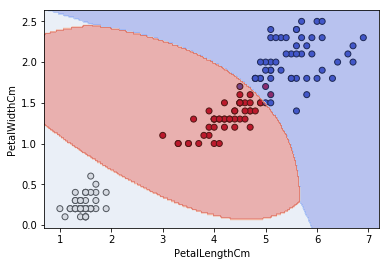

```python
plot_decision_boundaries(perc_model.predict)
```

```python
lr_model.fit(X_train, y_train)
lr_model.score(X_val, y_val)
```

```
0.94
```

Vediamo i decision boundaries del modello basato su regressione logistica

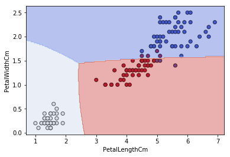

```python
plot_decision_boundaries(lr_model.predict)
```

```python
svm_model.fit(X_train, y_train)
svm_model.score(X_val, y_val)
```

```
0.98
```

Per il modello basato su svm, evidenziamo di rosso i support vectors, ossia i punti più vicini ai bordi, che vengono usati per effettuare le predizioni

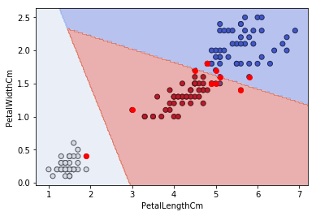

```python
plot_decision_boundaries(svm_model.predict)
for point in svm_model.named_steps["svc"].support_vectors_:
    plt.plot(point[0], point[1], 'ro')
```

Osserviamo che i tre modelli risultano meno aderenti ai dati rispetto al primo modello, possiamo pensare che saranno più precisi di questo sui dati futuri

## Appendice: ensembling

Definiamo una funzione che ci permetta di predire la specie di un'osservazione x usando i tre modelli descritti sopra in modo congiunto. La tecnica di ensembling qui è del tutto banale: viene definita la probabilità di appartenenza a ogni classe facendo la media delle probabilità espresse dai tre modelli per tale classe, la classe assegnata è quella con maggiore probabilità

```python
def ensemble_predict(x):
    perc_prob = perc_model.decision_function(x)[0]
    lr_prob = lr_model.decision_function(x)[0]
    svm_prob = svm_model.decision_function(x)[0]
    prob_c1 = (perc_prob[0] + lr_prob[0] + svm_prob[0])/3
    prob_c2 = (perc_prob[1] + lr_prob[1] + svm_prob[1])/3
    prob_c3 = (perc_prob[2] + lr_prob[2] + svm_prob[2])/3
    max_prob = prob_c1
    c = 1
    if prob_c2 > max_prob:
        max_prob = prob_c2
        c = 2
    if prob_c3 > max_prob:
        max_prob = prob_c3
        c = 3
    return c

def ensemble_predict_aggregate(X):
    y = []
    for i in range(0, len(X)):
        if isinstance(X, pd.DataFrame):
            y.append(ensemble_predict(X.iloc[[i], :]))
        else:
            y.append(ensemble_predict(X[[i], :]))
    return np.array(y)
```

Visualizziamo i decision boundaries ottenuti dall'ensembling dei tre modelli

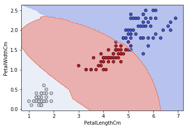

```python
plot_decision_boundaries(ensemble_predict_aggregate)
```